# Intro to R

2018-07-07

Data Analysis Using R - 2018-07-07

## R is case sensitive

*Important note: R is case-sensitive, meaning that it will matter whether you use capital or lower case, keep this in mind if you get a cryptic warning or error!*

## Help getting started with R

Writing R code can be challenging and espacially in the beginning you will get mind-boggling errors. R is extremely picky about capitals and every opening `(`, `[` or `{` must be matched by a closing `)`, `]` or `}`.

Mind that `.` is the decimal placeholder!

If you're stuck, try the help. You can get help about any R function by running `?function_name` and `?package_name` or `??package_name`, skip down to the examples and look for code that matches what you're trying to do.

Another great tool is Google: trying googling the error message, as it's likely someone else has had the same problem, and has gotten help online.

## Statistics and R

- This course does not cover statistical applications of R.
- Allbeit that we will look at an example of a linear regression later on.
- Nowadays R is a versatile language and can be used for various applications, but it was originally designed as a language for performing statistical analyses.
- This is why very many statistical applcations are available for R.
- To start learning about statisics and R, I can highly recommend the book "Discovering Statistics Using R" by Dr. Andy Field: https://uk.sagepub.com/en-gb/eur/discovering-statistics-using-r/book236067%20

## For more on learning R in the context of statistics: start e.g. with:

http://www.statsteachr.org/ or

https://www.coursera.org/learn/statistical-inference/home/welcome or

https://www.youtube.com/watch?v=ACWuV16tdhY&index=21&list=PLqzoL9-eJTNBDdKgJgJzaQcY6OXmsXAHU and

https://www.youtube.com/watch?v=kvmSAXhX9Hs&index=29&list=PLqzoL9-eJTNBDdKgJgJzaQcY6OXmsXAHU

and the rest of Mike Marin's lectures, that are also a really great way to start learning R.

## Packages

## List of available CRAN packages

http://cran.r-project.org/web/packages/available_packages_by_date.html

For the course we use `tidyverse` a lot

```r
# install.packages("tidyverse")
library(tidyverse)
```

The `tidyverse` (in itself an R-package) is actually a collection of packages! See: http://tidyr.tidyverse.org/ for more info

## Biological Packages

For Biological application go to http://www.bioconductor.org

Installing Bioconductor packages is different from CRAN packages example: `{affy}`

Each Bioconductor package has a landing page:

https://www.bioconductor.org/packages/release/bioc/html/affy.html

```r
## installing `{affy}` package
## try http:// if https:// URLs are not supported
source("https://bioconductor.org/biocLite.R")
biocLite("affy")

## loading affy package and the vignettes pages of this package
# library(affy)
# browseVignettes("affy")
```

## Vignettes

Vignettes are long explanations and demos of a package. Commonly, a vignette contains examples and a workflow that shows how the package can be used and which (research) questions can be adressed with the functions and datasets in the package. It usually is a good place to start for examples. It also shows the so-called dependence of a package: it explains which other packages you would need and how the data should look to be able to work with the package the vignette belongs to.

## Getting Help for R functions and packages

```r
#install.packages("dplyr")
library(dplyr)
library(ggplot2)
??dplyr
??ggplot2
?mean
??mean  # goes to the page with functions related with '.mean.'
apropos("mean") # search on more options of or alternatives for a certain function
```

## Examples and demos on functions and packages

```r
example(mean) # to see a worked example
demo(graphics) # demonstration of R functions
```

## Functions; naming arguments

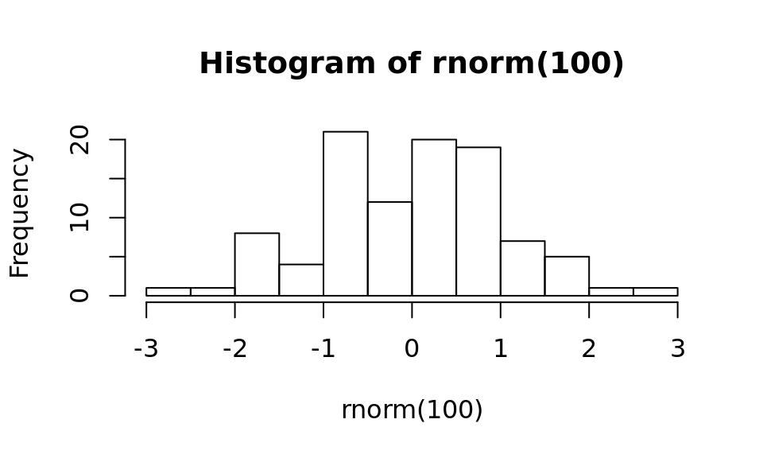

```r
# ?rnorm
hist(rnorm(100))
```

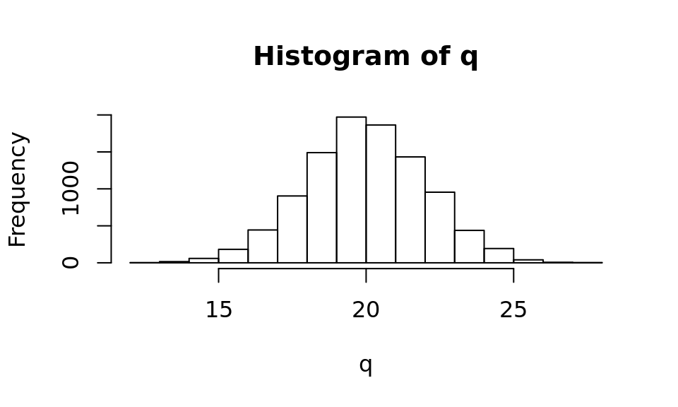

```r
seed <- c(1:4)

set.seed(seed)
q <- rnorm(n = 10000, mean = 20, sd = 2)
hist(q)
```

```r
## no naming
# set.seed(1234)
qq <- rnorm(10000, 20, 2)
all(q == qq)
```

```
## [1] FALSE
```

**Write code for humans, be explicit!**

## Data objects

## Vectors

R is an object oriented language: meaning you can create and work with (manipulate/index/access) objects. Vectors are R's elementary objects and come in different flavours:

- Nummeric vector: contains only numbers: decimal separator in R is "." (decimal point) and not "," (decimal comma) as is common in the English language.
- Character vector: contains only "words", but words can also be numbers: "23" or other items "100%" or "$2,000.00"
- An integer vector: an nummeric series: 1, 2, 3 is an integer of length 3.
- Logical: logical vectors contain only two values: "TRUE" and/or "FALSE"
- Mixed: Vectors do not need to be of one type. They can be mixed. They can only be of one class, so this operation will induce *coercion*.

## Numeric vectors

```r
c(2,8,5)    # combines its arguments to form a vector
```

```
## [1] 2 8 5
```

```r
nv_1 <- c(2,8,5) # assignment statement
nv_1 # view the content of the object "nv_1"
```

```
## [1] 2 8 5
```

## Class tells you about the classification

```r
nv_2 <- c(8.4,5.6,10.1,13.1,2.5,7.8,15.2,3.8,20.9)
nv_2
```

```
## [1]  8.4  5.6 10.1 13.1  2.5  7.8 15.2  3.8 20.9
```

```r
class(nv_2)
```

```
## [1] "numeric"
```

## Number notations and rounding

## Scientific notations

```r
big_numbers <- rnorm(10, mean = 10000000, sd = 2)
big_numbers %>% formatC(format = "e", digits = 2)
```

```
##  [1] "1.00e+07" "1.00e+07" "1.00e+07" "1.00e+07" "1.00e+07" "1.00e+07"
##  [7] "1.00e+07" "1.00e+07" "1.00e+07" "1.00e+07"
```

## Rounding numbers

```r
small_numbers <- runif(10, min = 0.001, max = 0.1) %>% print()
```

```
##  [1] 0.08122375 0.09752307 0.07132969 0.00143630 0.03941027 0.02480030
##  [7] 0.02574471 0.03331861 0.02447820 0.04184928
```

```r
small_numbers %>% round(digits = 2)
```

```
##  [1] 0.08 0.10 0.07 0.00 0.04 0.02 0.03 0.03 0.02 0.04
```

## Character vectors

```r
cv <- c("this is", "an", "example of", "1", "character", "vector", "with length:", "length(cv)")
cv
```

```
## [1] "this is"      "an"           "example of"   "1"
## [5] "character"    "vector"       "with length:" "length(cv)"
```

```r
length(cv)
```

```
## [1] 8
```

```r
class(cv)
```

```
## [1] "character"
```

## Integers

```r
int <- as.integer(1:5)
int
```

```
## [1] 1 2 3 4 5
```

```r
length(int)
```

```
## [1] 5
```

```r
class(int)
```

```
## [1] "integer"
```

## Logical vectors

```r
lv <- c(TRUE, FALSE, TRUE, TRUE)
lv
```

```
## [1]  TRUE FALSE  TRUE  TRUE
```

```r
class(lv)
```

```
## [1] "logical"
```

```r
## logical vectors can also be converted to numeric vectors
nlv <- as.numeric(lv)
nlv
```

```
## [1] 1 0 1 1
```

```r
## note that coercion of a logical to a numeric vector changes the "TRUE" value to 1 and the "FALSE" value to 0
```

## Manipulating vectors

You can add/subtract/devide or use other arithmetic functions on numeric vectors

```r
a <- c(1,3,5,7,9)
b <- c(2,4,6,8,10)
z1 <- a - b
z1
```

```
## [1] -1 -1 -1 -1 -1
```

```r
z2 <- b - a
z2
```

```
## [1] 1 1 1 1 1
```

```r
z3 <- a / b
z3
```

```
## [1] 0.5000000 0.7500000 0.8333333 0.8750000 0.9000000
```

## Apply functions to a vector

```r
z4 <- sum(a)
z4
```

```
## [1] 25
```

```r
z5 <- max(a) - max(b)
z5
```

```
## [1] -1
```

## Series in base-R

```r
numbers_times <- rep(1:4, times = 4) %>% print()
```

```
##  [1] 1 2 3 4 1 2 3 4 1 2 3 4 1 2 3 4
```

```r
numbers_each <- rep(1:4, each = 4) %>% print()
```

```
##  [1] 1 1 1 1 2 2 2 2 3 3 3 3 4 4 4 4
```

## Series in `{tidyverse}`

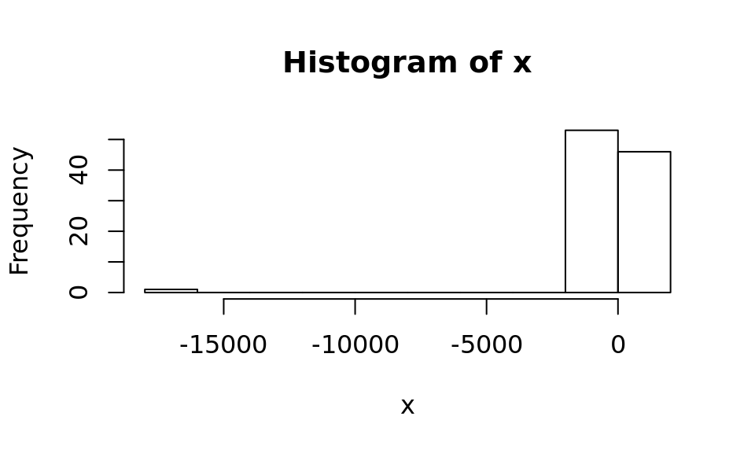

```r
library(modelr)
x <- rcauchy(100)
hist(x)
```

## More `{tidyverse}` series

```r
seq_range(x, n = 10)
```

```
##  [1] -17317.06778 -15390.99448 -13464.92118 -11538.84789  -9612.77459
##  [6]  -7686.70129  -5760.62800  -3834.55470  -1908.48140     17.59189
```

```r
seq_range(x, n = 10, trim = 0.1)
```

```
##  [1] -5.8119360 -4.5213904 -3.2308448 -1.9402992 -0.6497536  0.6407920
##  [7]  1.9313375  3.2218831  4.5124287  5.8029743
```

```r
seq_range(x, by = 1, trim = 0.1)
```

```
##  [1] -5.811936 -4.811936 -3.811936 -2.811936 -1.811936 -0.811936  0.188064
##  [8]  1.188064  2.188064  3.188064  4.188064  5.188064
```

## Make pretty `{tidyverse}` sequences

```r
y <- runif(100)
seq_range(y, n = 10)
```

```
##  [1] 0.01990147 0.12587704 0.23185262 0.33782819 0.44380376 0.54977934
##  [7] 0.65575491 0.76173049 0.86770606 0.97368163
```

```r
seq_range(y, n = 10, pretty = TRUE)
```

```
##  [1] 0.0 0.1 0.2 0.3 0.4 0.5 0.6 0.7 0.8 0.9 1.0
```

```r
seq_range(y, n = 10, expand = 0.5, pretty = TRUE)
```

```
##  [1] -0.4 -0.2  0.0  0.2  0.4  0.6  0.8  1.0  1.2  1.4
```

## Indexing with […]

You can get the individual items of a vector by using the index `[]`

```r
x <- c(8, 5, 10, 13, 2, 7, 15, 3, 20, 8)
x # create vector with 10 variables
```

```
##  [1]  8  5 10 13  2  7 15  3 20  8
```

```r
length(x)
```

```
## [1] 10
```

```r
mode(x) # information on data mode (numeric, character, logic)
```

```
## [1] "numeric"
```

## Using the index

```r
x
```

```
##  [1]  8  5 10 13  2  7 15  3 20  8
```

```r
x[3] ## creating a subset by indexing:
```

```
## [1] 10
```

```r
x[c(3, 4, 7)] # apply a simple function
```

```
## [1] 10 13 15
```

```r
mean(x[c(2,5)]) # example of a function
```

```
## [1] 3.5
```

## Using the vector index `[]` some more

```r
i <- 5
x[c(i, i+2)] # (i = 5 & i = 7), i-th element
```

```
## [1]  2 15
```

```r
x[-2] # all but the ith (second) element
```

```
## [1]  8 10 13  2  7 15  3 20  8
```

```r
x[3:5] # element 3 to 5
```

```
## [1] 10 13  2
```

```r
x[x > 9] # all greater than some value
```

```
## [1] 10 13 15 20
```

## Plotting and filtering elements from a vector

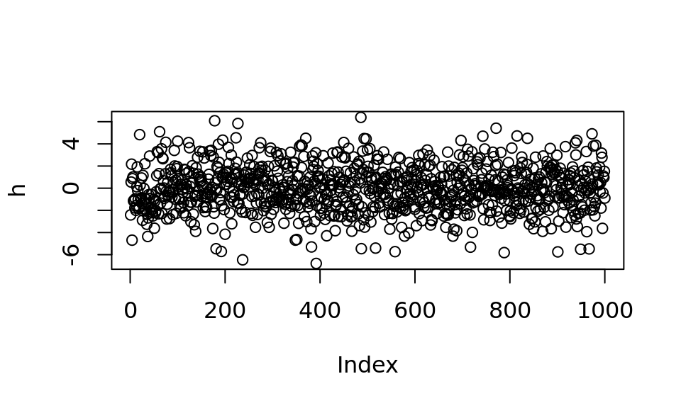

```r
set.seed(1234)
h <- rnorm(n = 1000, mean =  0, sd = 2)
plot(h)
```

```r
h
```

```
##    [1] -2.414131499  0.554858484  2.168882353 -4.691395405  0.858249378
##    [6]  1.012111784 -1.149479920 -1.093263712 -1.128903998 -1.780075658
##   [11] -0.954385400 -1.996772890 -1.552507789  0.128917635  1.918988118
##   [16] -0.220570989 -1.022019012 -1.822390833 -1.674343361  4.831670357
##   [21]  0.268176440 -0.981371793 -0.881095745  0.919178882 -1.387440494
##   [26] -2.896409821  1.149511442 -2.047311446 -0.030276601 -1.871897202
##   [31]  2.204595092 -0.951186158 -1.418880075 -1.002516121 -3.258186938
##   [36] -2.335238524 -4.360079298 -2.681986384 -0.588587718 -0.931795081
##   [41]  2.898992531 -2.137285447 -1.710729267 -0.561246004 -1.988680153
##   [46] -1.937028636 -2.214636385 -2.503971771 -1.047656238 -0.993699915
##   [51] -3.612062514 -1.164151849 -2.217779249 -2.029924019 -0.324619047
##   [56]  1.126111638  3.295634946 -1.546706848  3.211819258 -2.315617095
##   [61]  1.313176929  5.097982141 -0.069520780 -1.339267159 -0.015209511
##   [66]  3.554168896 -2.277215474  2.735654359  2.659129582  0.672945594
##   [71]  0.013785677 -0.910937476 -0.733047866  1.296573135  4.140541723
```

[output cut: 185 more lines]

```r
max(h)
```

```
## [1] 6.391802
```

```r
min(h)
```

```
## [1] -6.792127
```

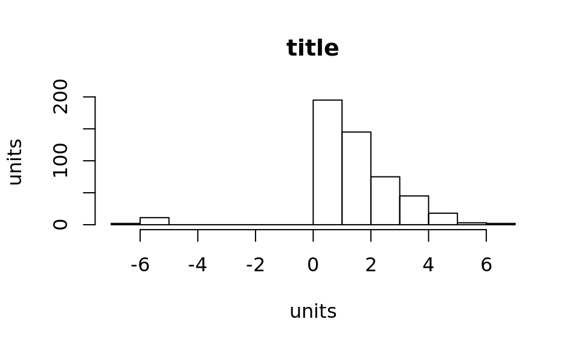

```r
hist(h[larger_than_0 <- h > 0 | h < -5], main = "title", xlab = "units",
     ylab = "units")
```

## Creating a logical index and apply it to a plot

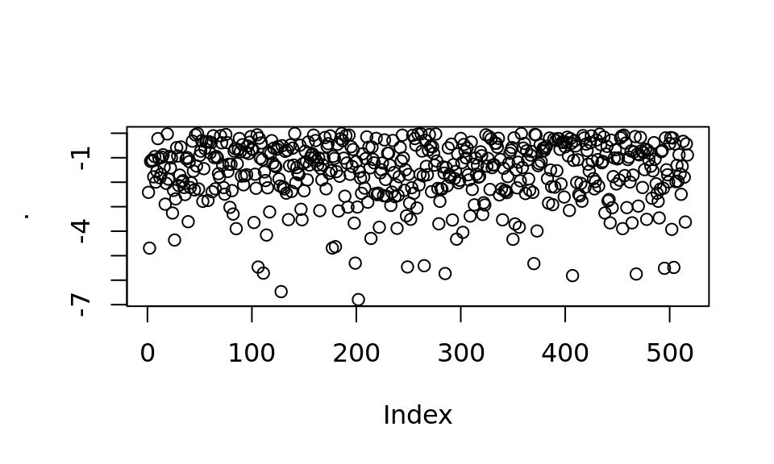

```r
ind <- h < 0
h[ind] %>% plot()
```

## Histogram

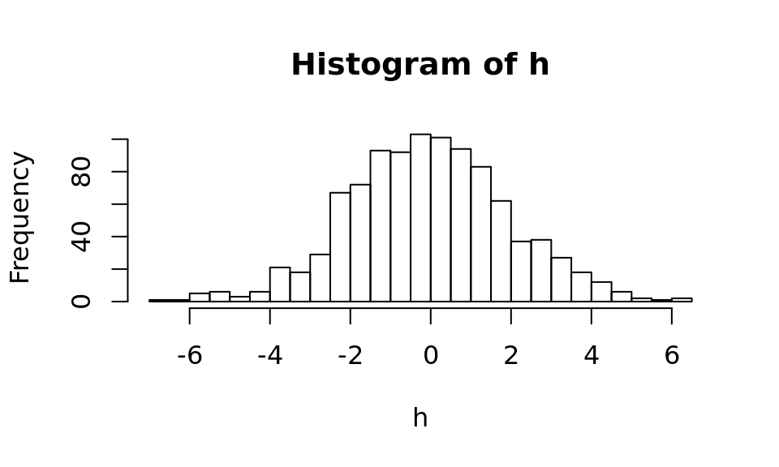

```r
hist(h, breaks = 20)
```

## Truncate the distribution at -4 and 4

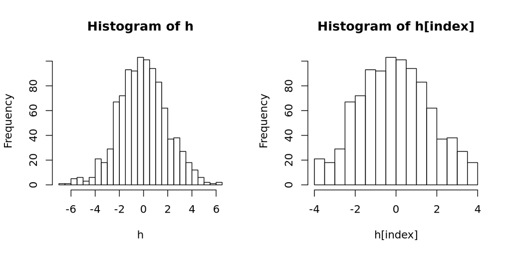

```r
index <- h > -4 & h < 4
par(mfrow = c(1,2))
hist(h, breaks = 20)
hist(h[index], breaks = 20)
```

## Concatenate or `c()` command

The `c()` function can be used to **concatenate**, **combine** or **create** objects in R

```r
pp <- c(x, 0, x)
pp
```

```
##  [1]  8  5 10 13  2  7 15  3 20  8  0  8  5 10 13  2  7 15  3 20  8
```

```r
sum(c(pp, c(1:5), c(1,2, c(1:10)))) # sum of elements in the 'concatenated' vector
```

```
## [1] 255
```

## Plotting models

```r
c <- c(1:7,9,11) # dependent variable (response)
d <- c(1:9) # independent variable (terms)
```

## Performing a linear correlation (response ~ terms)

```r
m1 <- lm(c ~ d)
m1$coefficients
```

```
## (Intercept)           d
##  -0.5833333   1.1833333
```

## Model summary

```r
summary(m1)
```

```
##
## Call:
## lm(formula = c ~ d)
##
## Residuals:
##      Min       1Q   Median       3Q      Max
## -0.70000 -0.33333  0.03333  0.21667  0.93333
##
## Coefficients:
##             Estimate Std. Error t value Pr(>|t|)
## (Intercept) -0.58333    0.38670  -1.508    0.175
## d            1.18333    0.06872  17.220 5.47e-07 ***
## ---
## Signif. codes:  0 '***' 0.001 '**' 0.01 '*' 0.05 '.' 0.1 ' ' 1
##
## Residual standard error: 0.5323 on 7 degrees of freedom
## Multiple R-squared:  0.9769, Adjusted R-squared:  0.9736
## F-statistic: 296.5 on 1 and 7 DF,  p-value: 5.47e-07
```

## Make a plot

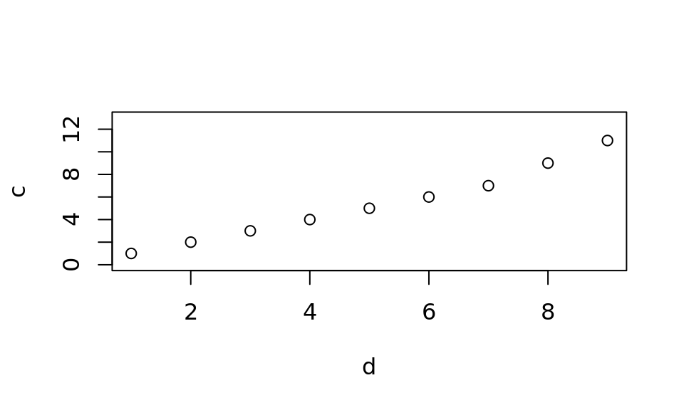

```r
plot(d, c, ylim=c(0,13))
```

## Plotting the model

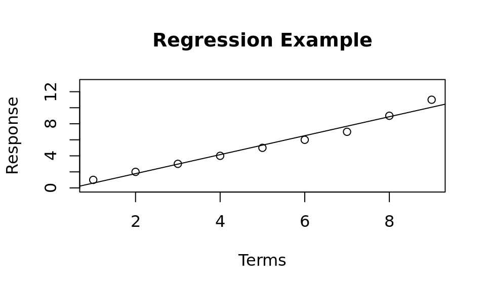

```r
plot(d, c, ylim=c(0,13), abline(m1),
     main = "Regression Example",
     xlab = "Terms", ylab = "Response")  #abline plots the correlation model in the graph
```

## ggplot2 version

During the course we will mostly use the `ggplot2` plotting system! ggplot2 works with dataframes, so we first need to create one

```r
tbl_df <- tibble(x = d, y = c)
```

## ggplot code

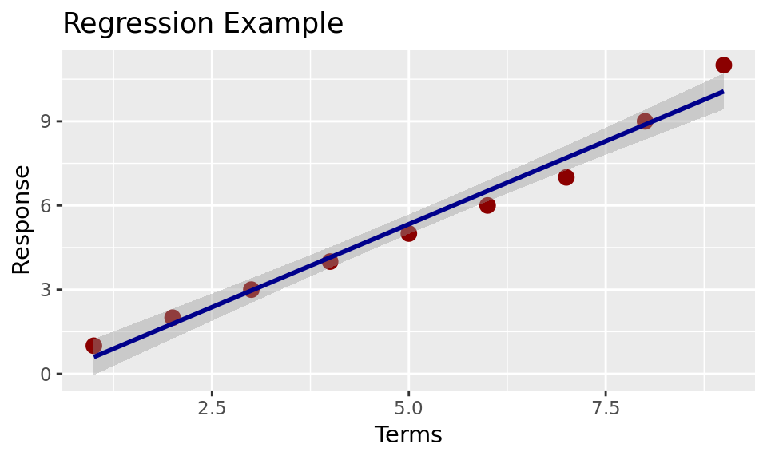

```r
ggplot(data = tbl_df, aes(x = x, y = y)) +
  geom_point(colour = "darkred", size = 3) +
  geom_smooth(method = "glm", se = TRUE, formula = y ~ x, colour =         "darkblue") +
  ggtitle("Regression Example") + xlab("Terms") + ylab("Response")
```

## Combine the two in one slide

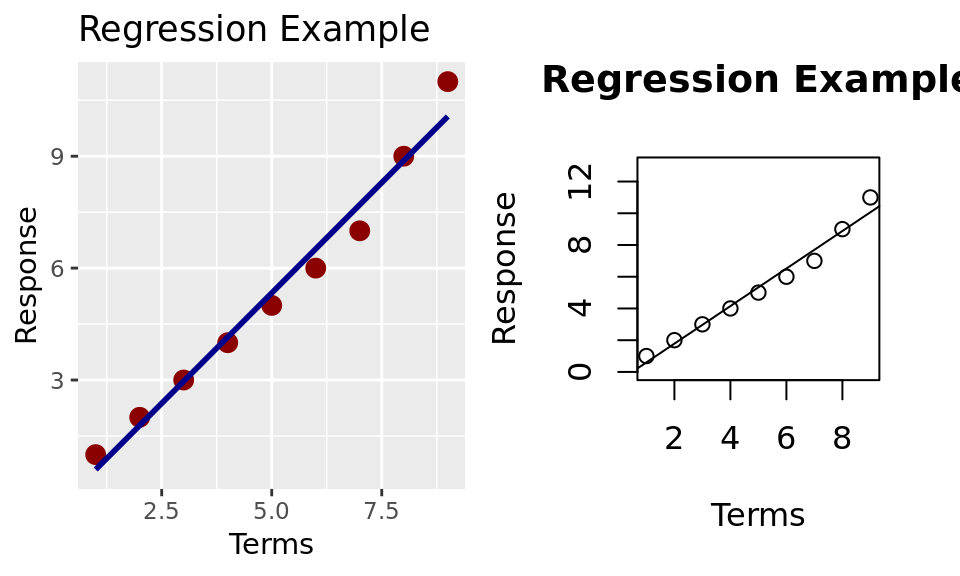

## Handeling character vectors

What happens if you use arithmetic functions on character vectors and numeric vectors?

```r
w <- c("1", "2")
u <- c("a", "b", "c")
z6 <- w-y
z7 <- u+w
```

This does not work because the vectors are of different type. We can use the paste command for this

```r
w <- c("1", "2")
u <- c("a", "b", "c")
z8 <- paste(u,w, sep = "_")
z8 ## because w is shorter than u, it get's recycled over u
```

```
## [1] "a_1" "b_2" "c_1"
```

## Let's clean up the workspace

```r
rm(list=ls())
root <- find_root_file(criterion = is_rstudio_project)
## Note: never use this in code that is meant for others!!!
```

*The above is an effective way to clear all the items in the Global Environment, but is is not very friendly to use this in code you share with others: can you think of why?*

## Data Structures: Lists

When using R for data analysis you will most likely work with data in a matrix, an array, a list or even more likely: a dataframe.

A matrix is a table with only numeric values. An array consists of multiple matices. A list is collection of R objects of different data type. A dataframe is a table with variable names in the first row and observations in the consecutive rows. The columns in a dataframe represnet different variables.

The dataframe and the list are the most widely used datastructures when considering experimental Biological data.

## Create a List

```r
lst <-list(first_names = c(male = "Fred", female = "Mary"), no.children = 3, child_ages=c(4,7,9),
child_names = c("Suzy", "Marvin", "Jane"), address = c("Pandmonium Alley 114, Chaosville"),
marital_status = TRUE)
length(lst) # number of elements in the list
```

```
## [1] 6
```

```r
head(lst, 2)
```

```
## $first_names
##   male female
## "Fred" "Mary"
##
## $no.children
## [1] 3
```

## Accessing items in a list

```r
lst[[1]] # 1st element of List
```

```
##   male female
## "Fred" "Mary"
```

```r
lst[[3]][2] # second item of third element
```

```
## [1] 7
```

```r
names(lst) # named elements in this list
```

```
## [1] "first_names"    "no.children"    "child_ages"     "child_names"
## [5] "address"        "marital_status"
```

```r
lst$child_names # pull "named" elements from a list using `$` operator
```

```
## [1] "Suzy"   "Marvin" "Jane"
```

## `str()` gives you the structure of an object

```r
str(lst) # display structure of lst
```

```
## List of 6
##  $ first_names   : Named chr [1:2] "Fred" "Mary"
##   ..- attr(*, "names")= chr [1:2] "male" "female"
##  $ no.children   : num 3
##  $ child_ages    : num [1:3] 4 7 9
##  $ child_names   : chr [1:3] "Suzy" "Marvin" "Jane"
##  $ address       : chr "Pandmonium Alley 114, Chaosville"
##  $ marital_status: logi TRUE
```

The new RStudio Interface also enables interactive exploration of R-objects (demo)

## Selecting single elements in a list

To select a single element from a variable in a list

```r
lst$child_ages[3]
```

```
## [1] 9
```

```r
lst[[6]][2] # returns the value of the second element for your variable
```

```
## [1] NA
```

## Looping over lists

```r
purrr::map(lst, is.na)
```

```
## $first_names
##   male female
##  FALSE  FALSE
##
## $no.children
## [1] FALSE
##
## $child_ages
## [1] FALSE FALSE FALSE
##
## $child_names
## [1] FALSE FALSE FALSE
##
## $address
## [1] FALSE
##
## $marital_status
## [1] FALSE
```

## The Dataframe

The dataframe is the most widely used data structure in the context of experimental biology and chemistry. **Remember "Tidy data!"**

## Creating a data frame from individual vectors

```r
people_df <- data.frame(age=c(24, 27, 19, 34),
                       sex=c("F","F","M", "M"),
                       weight=c(64, 55, 80, 70),
                       names = c("Christa", "Suzan",
                                 "Matt", "John"))
head(people_df)
```

```
##   age sex weight   names
## 1  24   F     64 Christa
## 2  27   F     55   Suzan
## 3  19   M     80    Matt
## 4  34   M     70    John
```

## Or the 'tidyverse' way

```r
people_tbl <- tibble::tibble(age=c(24, 27, 19, 34),
                       sex=c("F","F","M", "M"),
                       weight=c(64, 55, 80, 70),
                       names = c("Christa", "Suzan",
                                 "Matt", "John"))
people_tbl
```

```
## # A tibble: 4 x 4
##     age sex   weight names
##   <dbl> <chr>  <dbl> <chr>
## 1    24 F         64 Christa
## 2    27 F         55 Suzan
## 3    19 M         80 Matt
## 4    34 M         70 John
```

## Viewing the contents of a dataframe

```r
summary(people_df)
```

```
##       age        sex       weight          names
##  Min.   :19.00   F:2   Min.   :55.00   Christa:1
##  1st Qu.:22.75   M:2   1st Qu.:61.75   John   :1
##  Median :25.50         Median :67.00   Matt   :1
##  Mean   :26.00         Mean   :67.25   Suzan  :1
##  3rd Qu.:28.75         3rd Qu.:72.50
##  Max.   :34.00         Max.   :80.00
```

```r
table(people_df)
```

```
## , , weight = 55, names = Christa
##
##     sex
## age  F M
##   19 0 0
##   24 0 0
##   27 0 0
##   34 0 0
##
## , , weight = 64, names = Christa
##
##     sex
## age  F M
##   19 0 0
##   24 1 0
##   27 0 0
##   34 0 0
##
## , , weight = 70, names = Christa
##
##     sex
## age  F M
##   19 0 0
##   24 0 0
##   27 0 0
##   34 0 0
##
## , , weight = 80, names = Christa
##
##     sex
## age  F M
##   19 0 0
##   24 0 0
##   27 0 0
##   34 0 0
##
## , , weight = 55, names = John
##
##     sex
## age  F M
```

[output cut: 88 more lines]

```
##     sex
## age  F M
##   19 0 0
##   24 0 0
##   27 0 0
##   34 0 0
##
## , , weight = 80, names = Suzan
##
##     sex
## age  F M
##   19 0 0
##   24 0 0
##   27 0 0
##   34 0 0
```

```r
head(people_df)             # gives the content of the data frame
```

```
##   age sex weight   names
## 1  24   F     64 Christa
## 2  27   F     55   Suzan
## 3  19   M     80    Matt
## 4  34   M     70    John
```

```r
names(people_df)
```

```
## [1] "age"    "sex"    "weight" "names"
```

```r
str(people_df)
```

```
## 'data.frame':    4 obs. of  4 variables:
##  $ age   : num  24 27 19 34
##  $ sex   : Factor w/ 2 levels "F","M": 1 1 2 2
##  $ weight: num  64 55 80 70
##  $ names : Factor w/ 4 levels "Christa","John",..: 1 4 3 2
```

```r
people_df$age # gives the content of the variable "age" from the data frame ""
```

```
## [1] 24 27 19 34
```

## Using index on dataframes

Using the index "[]" on a dataframe is a bit tricky. The dataframe always consists of rows and columns. Indexing a dataframe goes like:

`dataframe[row number(s), column number(s)]`

```r
people_df$age[1]    # first element of this vector
```

```
## [1] 24
```

```r
people_df[,2]   # content of 2nd variable (column) which is a character vector -> factor
```

```
## [1] F F M M
## Levels: F M
```

```r
people_df[1,]   # content of the 1st row
```

```
##   age sex weight   names
## 1  24   F     64 Christa
```

```r
# multiple indices
people_df[2:3, c(1,3)] # remember to use c
```

```
##   age weight
## 2  27     55
## 3  19     80
```

## Import data into R

```r
library(tidyverse)
path_to_gender_age_data <- file.path(root, "data", "gender.txt")
gender_age <- read_delim(path_to_gender_age_data,
                         delim = "/")
```

## Inspecting the dataframe

```r
# getting the first few rows
head(gender_age)
```

```
## # A tibble: 6 x 2
##   gender   age
##   <chr>  <int>
## 1 F         12
## 2 F         23
## 3 F         34
## 4 M         12
## 5 M         15
## 6 M         17
```

```r
# getting information on the variable, the dimensions
str(gender_age)
```

```
## Classes 'tbl_df', 'tbl' and 'data.frame':    17 obs. of  2 variables:
##  $ gender: chr  "F" "F" "F" "M" ...
##  $ age   : int  12 23 34 12 15 17 18 14 56 67 ...
##  - attr(*, "spec")=List of 2
##   ..$ cols   :List of 2
##   .. ..$ gender: list()
##   .. .. ..- attr(*, "class")= chr  "collector_character" "collector"
##   .. ..$ age   : list()
##   .. .. ..- attr(*, "class")= chr  "collector_integer" "collector"
##   ..$ default: list()
##   .. ..- attr(*, "class")= chr  "collector_guess" "collector"
##   ..- attr(*, "class")= chr "col_spec"
```

```r
# selecting a variable
gender_age$gender
```

```
##  [1] "F" "F" "F" "M" "M" "M" "F" "F" "M" "F" "M" "M" "M" "F" "F" "F" "M"
```

```r
gender_age$age
```

```
##  [1] 12 23 34 12 15 17 18 14 56 67 89 34 45 12  3  5  4
```

```r
gender_age[1:6,2]
```

```
## # A tibble: 6 x 1
##     age
##   <int>
## 1    12
## 2    23
## 3    34
## 4    12
## 5    15
## 6    17
```

## read_csv

CSV is a format of a data file that uses commas or semicolons as separators for the columns.

```r
library(readr)
skin <- read_csv(paste0(root, "/data/skincolumns.csv"))
str(skin)
```

```
## Classes 'tbl_df', 'tbl' and 'data.frame':    15 obs. of  2 variables:
##  $ Genotype A: num  54.9 48.8 50.8 45 28.7 ...
##  $ Genotype B: num  30.5 24.8 24.2 27.9 18.8 ...
##  - attr(*, "spec")=List of 2
##   ..$ cols   :List of 2
##   .. ..$ Genotype A: list()
##   .. .. ..- attr(*, "class")= chr  "collector_double" "collector"
##   .. ..$ Genotype B: list()
##   .. .. ..- attr(*, "class")= chr  "collector_double" "collector"
##   ..$ default: list()
##   .. ..- attr(*, "class")= chr  "collector_guess" "collector"
##   ..- attr(*, "class")= chr "col_spec"
```

## Inspecting the skin dataframe

```r
head(skin)   # content of the data frame
```

```
## # A tibble: 6 x 2
##   `Genotype A` `Genotype B`
##          <dbl>        <dbl>
## 1         54.9         30.5
## 2         48.8         24.8
## 3         50.8         24.2
## 4         45.0         27.9
## 5         28.7         18.8
## 6         35.3         25.5
```

```r
dim(skin)
```

```
## [1] 15  2
```

```r
attributes(skin)
```

```
## $names
## [1] "Genotype A" "Genotype B"
##
## $row.names
##  [1]  1  2  3  4  5  6  7  8  9 10 11 12 13 14 15
##
## $class
## [1] "tbl_df"     "tbl"        "data.frame"
##
## $spec
```

```r
summary(skin)
```

```
##    Genotype A      Genotype B
##  Min.   :28.75   Min.   :18.76
##  1st Qu.:42.89   1st Qu.:23.95
##  Median :47.98   Median :25.16
##  Mean   :48.22   Mean   :25.73
##  3rd Qu.:53.04   3rd Qu.:27.40
##  Max.   :69.13   Max.   :31.59
##                  NA's   :1
```

```r
## ?read_csv     # help on the function
```

## `skin` dataset contains an NA, some functions do not work with NAs:

```r
mean(skin$`Genotype A`)
```

```
## [1] 48.22066
```

```r
mean(skin$`Genotype B`)
```

```
## [1] NA
```

```r
# to remove the NA
skin_noNA <- na.omit(skin)
mean(skin_noNA$`Genotype B`)
```

```
## [1] 25.72858
```

## Smoking example with multiple variables

Create data frame with 4 variables: gender, smoke, age, weigth

## Create individual vectors

```r
set.seed(6000) # set it at the same number, then we will all produce the same output
gender<-c(sample(c(1,2), size=1000, replace=TRUE))
smoke<-c(sample(c(1,2), size=1000, replace=TRUE))
age<-c(sample(c(1,2,3), size=1000, replace=TRUE))
weight<-round(rnorm(1000, mean=65, sd=10),1)
smoking <- data.frame(cbind(gender, smoke, age, weight))
```

## `head(x, ...)`

```r
head(smoking, 5)
```

```
##   gender smoke age weight
## 1      2     1   3   65.1
## 2      2     1   1   66.9
## 3      1     2   3   46.9
## 4      1     1   3   70.5
## 5      1     2   1   66.9
```

```r
smoking[1:5,]
```

```
##   gender smoke age weight
## 1      2     1   3   65.1
## 2      2     1   1   66.9
## 3      1     2   3   46.9
## 4      1     1   3   70.5
## 5      1     2   1   66.9
```

## Replace numbers by descriptive labels

```r
# replace numbers by characters
smoking$genderf=factor(smoking$gender, labels=c("female","male"))
table(smoking$genderf,smoking$gender)
```

```
##
##            1   2
##   female 497   0
##   male     0 503
```

```r
smoking$smokef=factor(smoking$smoke, labels=c("Y","N"))
table(smoking$smokef,smoking$smoke)
```

```
##
##       1   2
##   Y 521   0
##   N   0 479
```

```r
smoking$agecf=factor(smoking$age, labels=c("A: <15","B: 15-30","C: >30"))
table(smoking$agecf,smoking$age)
```

```
##
##              1   2   3
##   A: <15   332   0   0
##   B: 15-30   0 355   0
##   C: >30     0   0 313
```

```r
summary(smoking)
```

```
##      gender          smoke            age            weight
##  Min.   :1.000   Min.   :1.000   Min.   :1.000   Min.   :28.50
##  1st Qu.:1.000   1st Qu.:1.000   1st Qu.:1.000   1st Qu.:58.40
##  Median :2.000   Median :1.000   Median :2.000   Median :65.60
##  Mean   :1.503   Mean   :1.479   Mean   :1.981   Mean   :65.47
##  3rd Qu.:2.000   3rd Qu.:2.000   3rd Qu.:3.000   3rd Qu.:72.50
##  Max.   :2.000   Max.   :2.000   Max.   :3.000   Max.   :98.60
##    genderf    smokef       agecf
##  female:497   Y:521   A: <15  :332
##  male  :503   N:479   B: 15-30:355
##                       C: >30  :313
##
##
##
```

## Subsetting data frame; the easier {dplyr} way

```r
library(tidyverse)
names(smoking)
```

```
## [1] "gender"  "smoke"   "age"     "weight"  "genderf" "smokef"  "agecf"
```

```r
smoking_male <- smoking %>% filter(genderf == "male")
smoking_age_gender <- smoking %>% select(genderf, agecf)
```

## Or the base-R way

```r
library(tidyverse)
names(smoking)
```

```
## [1] "gender"  "smoke"   "age"     "weight"  "genderf" "smokef"  "agecf"
```

```r
# create a logical index
smoking_male_index <- smoking[, "genderf"] == "male"
smoking_male <- smoking[smoking_male_index, ]
# slecting only age and gender
smoking_age_gender <- smoking_male[, c(1,3)]
```

## Summarizing data

For summarizing data there are many ways in R (as is the case with many operations). I find the dplyr way the most intuitive. Using dplyr has the advantage that you can easily built on existing function and examples, because the code is faily easy to understand.

## The pipe or %>% operator

- One thing that makes dplyr great is that it works with the `%>%` symbol. Which is in programming jargon also called the "pipe" symbol.
- The pipe symbol takes the previous result of an operation and put it in the next.
- The pipe symbol can replace the use of annoying round brackets: or "(parentheses)"

## Example

```r
library(dplyr)
set.seed(12345)
zzz <- sqrt(mean(x <- rnorm(10000, mean = 34, sd = 2))) +
sqrt(mean(y <- rnorm(10000, mean = 23, sd = 4)))
zzz
```

```
## [1] 10.6257
```

The above is almost impossible to read because of all the round brackets, note the closing brackets: 3 of them!!

## let's try the dplyr way with the %>% (pipe) operator

```r
set.seed(12345)
qqq <- rnorm(10000, mean = 34, sd = 2) %>%
  mean() %>%
  sqrt() + rnorm(10000, mean = 23, sd = 4) %>%
  mean() %>%
  sqrt()
qqq
```

```
## [1] 10.6257
```

```r
zzz == qqq
```

```
## [1] TRUE
```

The dplyr way is a lot better is it not? Do you get what the above (dplyr-way) lines do?

## Let's apply the above to our smoking dataset

- Usually, if we want to make a graph we need some sort of summarizing variable that indicates wat is going on, e.g. a group mean and standard deviation.
- From the smoking dataset we will genrate a new dataframe with average weight, grouped by gender, age and grouped by smoking or non smoking. We will use dplyr verse to do so.
- I will also show you how to sort the data, let's say to decreasing weight, by using the dplyr function 'arrange'.

## Summary of the smoking data

```r
## it is handy to have the names of the dataset variables at hand when writing pipes

names(smoking)
```

```
## [1] "gender"  "smoke"   "age"     "weight"  "genderf" "smokef"  "agecf"
```

```r
str(smoking)
```

```
## 'data.frame':    1000 obs. of  7 variables:
##  $ gender : num  2 2 1 1 1 2 1 1 1 2 ...
##  $ smoke  : num  1 1 2 1 2 2 1 2 2 1 ...
##  $ age    : num  3 1 3 3 1 3 1 3 3 1 ...
##  $ weight : num  65.1 66.9 46.9 70.5 66.9 93 67.1 74.5 77.6 61.6 ...
##  $ genderf: Factor w/ 2 levels "female","male": 2 2 1 1 1 2 1 1 1 2 ...
##  $ smokef : Factor w/ 2 levels "Y","N": 1 1 2 1 2 2 1 2 2 1 ...
##  $ agecf  : Factor w/ 3 levels "A: <15","B: 15-30",..: 3 1 3 3 1 3 1 3 3 1 ...
```

## Example `pipe`

```r
smoking_weight <- smoking %>% select(genderf, smokef, weight, agecf) %>%
  group_by(genderf, smokef, agecf) %>% summarise(mean_weight = mean(weight)) %>%
  arrange(desc(mean_weight))

head(smoking_weight)
```

```
## # A tibble: 6 x 4
## # Groups:   genderf, smokef [4]
##   genderf smokef agecf    mean_weight
##   <fct>   <fct>  <fct>          <dbl>
## 1 female  N      C: >30          67.1
## 2 female  Y      A: <15          66.9
## 3 male    Y      B: 15-30        66.8
## 4 female  Y      C: >30          66.4
## 5 male    Y      C: >30          65.5
## 6 male    N      B: 15-30        65.3
```

## Looking in detail at the pipe

Let's look at what is going on above.

The smoking_weight dataset contains newly created, more descriptive denominators, we will use those.

1. The first step is to inspect the dataframe to see if the grouping variables are set to "factor"
2. The second step is to select the proper variables to work with
3. Than the data is grouped by the genderf, agecf and by the smokef variables
4. Summarise creates a new variable `mean_weight` that is what it says: the mean weight for the groups defined.
5. Finally, the data is sorted, according the newly created mean_weight variable, in decending order "(dec(mean_weight))". If we want ascending order we can just use arrange(mean_weight). Arrange has the default to order the variable in ascending order.